# 泰坦尼克生存预测

## 双击查看数据含义

survival Survival (0 = No; 1 = Yes) pclass Passenger Class (1 = 1st; 2 = 2nd; 3 = 3rd) name Name sex Sex age Age sibsp Number of Siblings/Spouses Aboard parch Number of Parents/Children Aboard ticket Ticket Number fare Passenger Fare cabin Cabin embarked Port of Embarkation (C = Cherbourg; Q = Queenstown; S = Southampton)

```python
import pandas as pd
import numpy as np
import matplotlib.pyplot as plt
import re
import seaborn as sns
%matplotlib inline
import xgboost as xgb

from sklearn.decomposition import PCA

from sklearn.ensemble import RandomForestClassifier, AdaBoostClassifier, GradientBoostingClassifier, ExtraTreesClassifier
from sklearn.svm import SVC
from sklearn.cross_validation import KFold
```

```python
train = pd.read_csv('train.csv')
test = pd.read_csv('test.csv')

PassengerId = test['PassengerId']
```

```python
train.head()
```

|  | PassengerId | Survived | Pclass | Name | Sex | Age | SibSp | Parch | Ticket | Fare | Cabin | Embarked |
| --- | --- | --- | --- | --- | --- | --- | --- | --- | --- | --- | --- | --- |
| 0 | 1 | 0 | 3 | Braund, Mr. Owen Harris | male | 22.0 | 1 | 0 | A/5 21171 | 7.2500 | NaN | S |
| 1 | 2 | 1 | 1 | Cumings, Mrs. John Bradley (Florence Briggs Th... | female | 38.0 | 1 | 0 | PC 17599 | 71.2833 | C85 | C |
| 2 | 3 | 1 | 3 | Heikkinen, Miss. Laina | female | 26.0 | 0 | 0 | STON/O2. 3101282 | 7.9250 | NaN | S |
| 3 | 4 | 1 | 1 | Futrelle, Mrs. Jacques Heath (Lily May Peel) | female | 35.0 | 1 | 0 | 113803 | 53.1000 | C123 | S |
| 4 | 5 | 0 | 3 | Allen, Mr. William Henry | male | 35.0 | 0 | 0 | 373450 | 8.0500 | NaN | S |

```python
train.tail()
```

|  | PassengerId | Survived | Pclass | Name | Sex | Age | SibSp | Parch | Ticket | Fare | Cabin | Embarked |
| --- | --- | --- | --- | --- | --- | --- | --- | --- | --- | --- | --- | --- |
| 886 | 887 | 0 | 2 | Montvila, Rev. Juozas | male | 27.0 | 0 | 0 | 211536 | 13.00 | NaN | S |
| 887 | 888 | 1 | 1 | Graham, Miss. Margaret Edith | female | 19.0 | 0 | 0 | 112053 | 30.00 | B42 | S |
| 888 | 889 | 0 | 3 | Johnston, Miss. Catherine Helen "Carrie" | female | NaN | 1 | 2 | W./C. 6607 | 23.45 | NaN | S |
| 889 | 890 | 1 | 1 | Behr, Mr. Karl Howell | male | 26.0 | 0 | 0 | 111369 | 30.00 | C148 | C |
| 890 | 891 | 0 | 3 | Dooley, Mr. Patrick | male | 32.0 | 0 | 0 | 370376 | 7.75 | NaN | Q |

```python
train.info() # 看出哪几列有空的，哪几列非数值
print '*'*40
test.info()
```

```
<class 'pandas.core.frame.DataFrame'>
RangeIndex: 891 entries, 0 to 890
Data columns (total 12 columns):
PassengerId    891 non-null int64
Survived       891 non-null int64
Pclass         891 non-null int64
Name           891 non-null object
Sex            891 non-null object
Age            714 non-null float64
SibSp          891 non-null int64
Parch          891 non-null int64
Ticket         891 non-null object
Fare           891 non-null float64
Cabin          204 non-null object
Embarked       889 non-null object
dtypes: float64(2), int64(5), object(5)
memory usage: 83.6+ KB
<class 'pandas.core.frame.DataFrame'>
RangeIndex: 418 entries, 0 to 417
Data columns (total 11 columns):
PassengerId    418 non-null int64
Pclass         418 non-null int64
Name           418 non-null object
Sex            418 non-null object
Age            332 non-null float64
SibSp          418 non-null int64
Parch          418 non-null int64
Ticket         418 non-null object
Fare           417 non-null float64
Cabin          91 non-null object
Embarked       418 non-null object
dtypes: float64(2), int64(4), object(5)
memory usage: 36.0+ KB
```

```python
train.describe() # 这会显示数值型的
```

|  | PassengerId | Survived | Pclass | Age | SibSp | Parch | Fare |
| --- | --- | --- | --- | --- | --- | --- | --- |
| count | 891.000000 | 891.000000 | 891.000000 | 714.000000 | 891.000000 | 891.000000 | 891.000000 |
| mean | 446.000000 | 0.383838 | 2.308642 | 29.699118 | 0.523008 | 0.381594 | 32.204208 |
| std | 257.353842 | 0.486592 | 0.836071 | 14.526497 | 1.102743 | 0.806057 | 49.693429 |
| min | 1.000000 | 0.000000 | 1.000000 | 0.420000 | 0.000000 | 0.000000 | 0.000000 |
| 25% | 223.500000 | 0.000000 | 2.000000 | NaN | 0.000000 | 0.000000 | 7.910400 |
| 50% | 446.000000 | 0.000000 | 3.000000 | NaN | 0.000000 | 0.000000 | 14.454200 |
| 75% | 668.500000 | 1.000000 | 3.000000 | NaN | 1.000000 | 0.000000 | 31.000000 |
| max | 891.000000 | 1.000000 | 3.000000 | 80.000000 | 8.000000 | 6.000000 | 512.329200 |

```python
train.describe(include=['O']) # 显示object类型
```

|  | Name | Sex | Ticket | Cabin | Embarked |
| --- | --- | --- | --- | --- | --- |
| count | 891 | 891 | 891 | 204 | 889 |
| unique | 891 | 2 | 681 | 147 | 3 |
| top | Graham, Mr. George Edward | male | CA. 2343 | C23 C25 C27 | S |
| freq | 1 | 577 | 7 | 4 | 644 |

```python
full_data = [train, test] # 放在一块儿同时进行数据预处理

for dataset in full_data:
    dataset['Name_length'] = dataset['Name'].apply(len)
    dataset['Has_Cabin'] = dataset['Cabin'].apply(lambda x: 0 if type(x) == float else 1)
    dataset['FamilySize'] = dataset['SibSp'] + dataset['Parch'] + 1
    dataset['IsAlone'] = 0
    dataset.loc[dataset['FamilySize'] == 1, 'IsAlone'] = 1
    dataset['Embarked'] = dataset['Embarked'].fillna('S')  # 如果Embarked列有空值，填充为S
    dataset['Fare'] = dataset['Fare'].fillna(train['Fare'].median())
    # 填充Age
    age_avg = dataset['Age'].mean()
    age_std = dataset['Age'].std()
    age_null_count = dataset['Age'].isnull().sum()
    age_null_random_list = np.random.randint(age_avg - age_std, age_avg + age_std, size=age_null_count)
    dataset['Age'][np.isnan(dataset['Age'])] = age_null_random_list
    dataset['Age'] = dataset['Age'].astype(int)

    dataset['Sex'] = dataset['Sex'].map( {'female': 0, 'male': 1} ).astype(int)
    dataset['Embarked'] = dataset['Embarked'].map( {'S': 0, 'C': 1, 'Q': 2} ).astype(int)
#     train['CategoricalFare'] = pd.qcut(train['Fare'], 4)
#     将Fare切成4份
    dataset.loc[ dataset['Fare'] <= 7.91, 'Fare'] 						        = 0
    dataset.loc[(dataset['Fare'] > 7.91) & (dataset['Fare'] <= 14.454), 'Fare'] = 1
    dataset.loc[(dataset['Fare'] > 14.454) & (dataset['Fare'] <= 31), 'Fare']   = 2
    dataset.loc[ dataset['Fare'] > 31, 'Fare'] 							        = 3
    dataset['Fare'] = dataset['Fare'].astype(int)
#     train['CategoricalAge'] = pd.cut(train['Age'], 5)
#     通过上面代码将Age切成5份
    dataset.loc[ dataset['Age'] <= 16, 'Age'] 					       = 0
    dataset.loc[(dataset['Age'] > 16) & (dataset['Age'] <= 32), 'Age'] = 1
    dataset.loc[(dataset['Age'] > 32) & (dataset['Age'] <= 48), 'Age'] = 2
    dataset.loc[(dataset['Age'] > 48) & (dataset['Age'] <= 64), 'Age'] = 3
    dataset.loc[ dataset['Age'] > 64, 'Age']  					       = 4 ;

train.head()
```

|  | PassengerId | Survived | Pclass | Name | Sex | Age | SibSp | Parch | Ticket | Fare | Cabin | Embarked | Name_length | Has_Cabin | FamilySize | IsAlone |
| --- | --- | --- | --- | --- | --- | --- | --- | --- | --- | --- | --- | --- | --- | --- | --- | --- |
| 0 | 1 | 0 | 3 | Braund, Mr. Owen Harris | 1 | 1 | 1 | 0 | A/5 21171 | 0 | NaN | 0 | 23 | 0 | 2 | 0 |
| 1 | 2 | 1 | 1 | Cumings, Mrs. John Bradley (Florence Briggs Th... | 0 | 2 | 1 | 0 | PC 17599 | 3 | C85 | 1 | 51 | 1 | 2 | 0 |
| 2 | 3 | 1 | 3 | Heikkinen, Miss. Laina | 0 | 1 | 0 | 0 | STON/O2. 3101282 | 1 | NaN | 0 | 22 | 0 | 1 | 1 |
| 3 | 4 | 1 | 1 | Futrelle, Mrs. Jacques Heath (Lily May Peel) | 0 | 2 | 1 | 0 | 113803 | 3 | C123 | 0 | 44 | 1 | 2 | 0 |
| 4 | 5 | 0 | 3 | Allen, Mr. William Henry | 1 | 2 | 0 | 0 | 373450 | 1 | NaN | 0 | 24 | 0 | 1 | 1 |

```python
def get_title(name):
    title_search = re.search(r' ([A-Za-z]+)\.', name)
    # If the title exists, extract and return it.
    if title_search:
        return title_search.group(1) # 返回括号里面的匹配项
    return ""

for dataset in full_data:
    dataset['Title'] = dataset['Name'].apply(get_title)
    dataset['Title'] = dataset['Title'].replace(['Lady', 'Countess','Capt', 'Col','Don', 'Dr', 'Major', 'Rev', 'Sir', 'Jonkheer', 'Dona'], 'Rare')
    dataset['Title'] = dataset['Title'].replace('Mlle', 'Miss')
    dataset['Title'] = dataset['Title'].replace('Ms', 'Miss')
    dataset['Title'] = dataset['Title'].replace('Mme', 'Mrs')

for dataset in full_data:
    title_mapping = {"Mr": 1, "Miss": 2, "Mrs": 3, "Master": 4, "Rare": 5}
    dataset['Title'] = dataset['Title'].map(title_mapping)
    dataset['Title'] = dataset['Title'].fillna(0)

train.head()
```

|  | PassengerId | Survived | Pclass | Name | Sex | Age | SibSp | Parch | Ticket | Fare | Cabin | Embarked | Name_length | Has_Cabin | FamilySize | IsAlone | Title |
| --- | --- | --- | --- | --- | --- | --- | --- | --- | --- | --- | --- | --- | --- | --- | --- | --- | --- |
| 0 | 1 | 0 | 3 | Braund, Mr. Owen Harris | 1 | 1 | 1 | 0 | A/5 21171 | 0 | NaN | 0 | 23 | 0 | 2 | 0 | 1 |
| 1 | 2 | 1 | 1 | Cumings, Mrs. John Bradley (Florence Briggs Th... | 0 | 2 | 1 | 0 | PC 17599 | 3 | C85 | 1 | 51 | 1 | 2 | 0 | 3 |
| 2 | 3 | 1 | 3 | Heikkinen, Miss. Laina | 0 | 1 | 0 | 0 | STON/O2. 3101282 | 1 | NaN | 0 | 22 | 0 | 1 | 1 | 2 |
| 3 | 4 | 1 | 1 | Futrelle, Mrs. Jacques Heath (Lily May Peel) | 0 | 2 | 1 | 0 | 113803 | 3 | C123 | 0 | 44 | 1 | 2 | 0 | 3 |
| 4 | 5 | 0 | 3 | Allen, Mr. William Henry | 1 | 2 | 0 | 0 | 373450 | 1 | NaN | 0 | 24 | 0 | 1 | 1 | 1 |

```python
# Feature selection
drop_elements = ['PassengerId', 'Name', 'Ticket', 'Cabin', 'SibSp']
train = train.drop(drop_elements, axis = 1)
# train = train.drop(['CategoricalAge', 'CategoricalFare'], axis = 1)
test  = test.drop(drop_elements, axis = 1)
```

```python
train.head()
```

|  | Survived | Pclass | Sex | Age | Parch | Fare | Embarked | Name_length | Has_Cabin | FamilySize | IsAlone | Title |
| --- | --- | --- | --- | --- | --- | --- | --- | --- | --- | --- | --- | --- |
| 0 | 0 | 3 | 1 | 1 | 0 | 0 | 0 | 23 | 0 | 2 | 0 | 1 |
| 1 | 1 | 1 | 0 | 2 | 0 | 3 | 1 | 51 | 1 | 2 | 0 | 3 |
| 2 | 1 | 3 | 0 | 1 | 0 | 1 | 0 | 22 | 0 | 1 | 1 | 2 |
| 3 | 1 | 1 | 0 | 2 | 0 | 3 | 0 | 44 | 1 | 2 | 0 | 3 |
| 4 | 0 | 3 | 1 | 2 | 0 | 1 | 0 | 24 | 0 | 1 | 1 | 1 |

```python
train.info()
print '!'*40
test.info()
```

```
<class 'pandas.core.frame.DataFrame'>
RangeIndex: 891 entries, 0 to 890
Data columns (total 12 columns):
Survived       891 non-null int64
Pclass         891 non-null int64
Sex            891 non-null int64
Age            891 non-null int64
Parch          891 non-null int64
Fare           891 non-null int64
Embarked       891 non-null int64
Name_length    891 non-null int64
Has_Cabin      891 non-null int64
FamilySize     891 non-null int64
IsAlone        891 non-null int64
Title          891 non-null int64
dtypes: int64(12)
memory usage: 83.6 KB
!!!!!!!!!!!!!!!!!!!!!!!!!!!!!!!!!!!!!!!!
<class 'pandas.core.frame.DataFrame'>
RangeIndex: 418 entries, 0 to 417
Data columns (total 11 columns):
Pclass         418 non-null int64
Sex            418 non-null int64
Age            418 non-null int64
Parch          418 non-null int64
Fare           418 non-null int64
Embarked       418 non-null int64
Name_length    418 non-null int64
Has_Cabin      418 non-null int64
FamilySize     418 non-null int64
IsAlone        418 non-null int64
Title          418 non-null int64
dtypes: int64(11)
memory usage: 36.0 KB
```

```python
train.describe()
```

|  | Survived | Pclass | Sex | Age | Parch | Fare | Embarked | Name_length | Has_Cabin | FamilySize | IsAlone | Title |
| --- | --- | --- | --- | --- | --- | --- | --- | --- | --- | --- | --- | --- |
| count | 891.000000 | 891.000000 | 891.000000 | 891.000000 | 891.000000 | 891.000000 | 891.000000 | 891.000000 | 891.000000 | 891.000000 | 891.000000 | 891.000000 |
| mean | 0.383838 | 2.308642 | 0.647587 | 1.354658 | 0.381594 | 1.505051 | 0.361392 | 26.965208 | 0.228956 | 1.904602 | 0.602694 | 1.728395 |
| std | 0.486592 | 0.836071 | 0.477990 | 0.839963 | 0.806057 | 1.118148 | 0.635673 | 9.281607 | 0.420397 | 1.613459 | 0.489615 | 1.030039 |
| min | 0.000000 | 1.000000 | 0.000000 | 0.000000 | 0.000000 | 0.000000 | 0.000000 | 12.000000 | 0.000000 | 1.000000 | 0.000000 | 1.000000 |
| 25% | 0.000000 | 2.000000 | 0.000000 | 1.000000 | 0.000000 | 0.500000 | 0.000000 | 20.000000 | 0.000000 | 1.000000 | 0.000000 | 1.000000 |
| 50% | 0.000000 | 3.000000 | 1.000000 | 1.000000 | 0.000000 | 2.000000 | 0.000000 | 25.000000 | 0.000000 | 1.000000 | 1.000000 | 1.000000 |
| 75% | 1.000000 | 3.000000 | 1.000000 | 2.000000 | 0.000000 | 2.000000 | 1.000000 | 30.000000 | 0.000000 | 2.000000 | 1.000000 | 2.000000 |
| max | 1.000000 | 3.000000 | 1.000000 | 4.000000 | 6.000000 | 3.000000 | 2.000000 | 82.000000 | 1.000000 | 11.000000 | 1.000000 | 5.000000 |

数据预处理结束

### 可视化 ,通过散布矩阵观察各个特征之间的相关性，pd的画图还是sns的漂亮啊

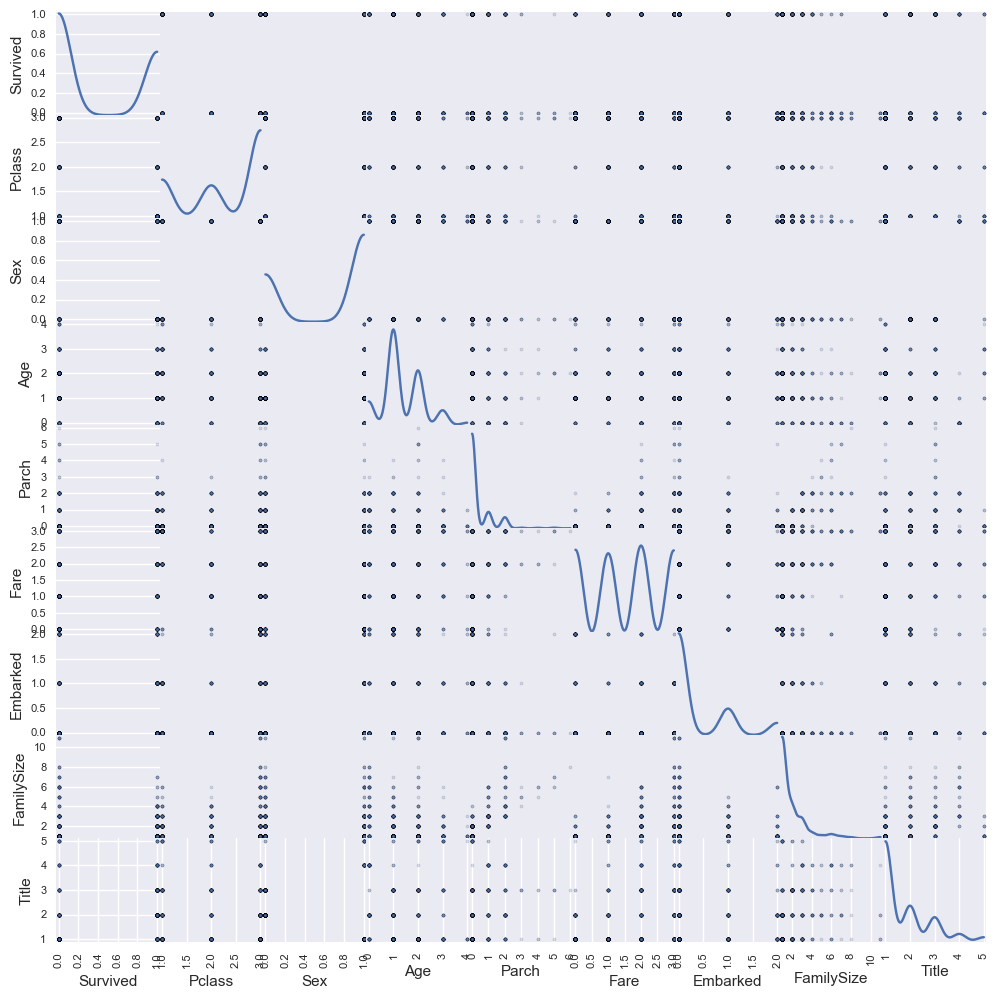

```python
pd.scatter_matrix(train[[u'Survived', u'Pclass', u'Sex', u'Age', u'Parch', u'Fare', u'Embarked',
       u'FamilySize', u'Title']], alpha=0.2, figsize=(12, 12), diagonal = 'kde');
```

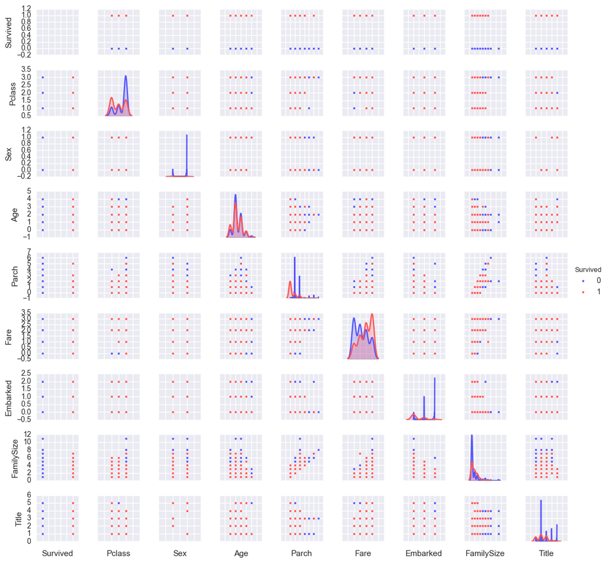

```python
g = sns.pairplot(train[[u'Survived', u'Pclass', u'Sex', u'Age', u'Parch', u'Fare', u'Embarked',
       u'FamilySize', u'Title']], hue='Survived', palette = 'seismic',size=1.2,diag_kind = 'kde',diag_kws=dict(shade=True),plot_kws=dict(s=10) )
g.set(xticklabels=[])
```

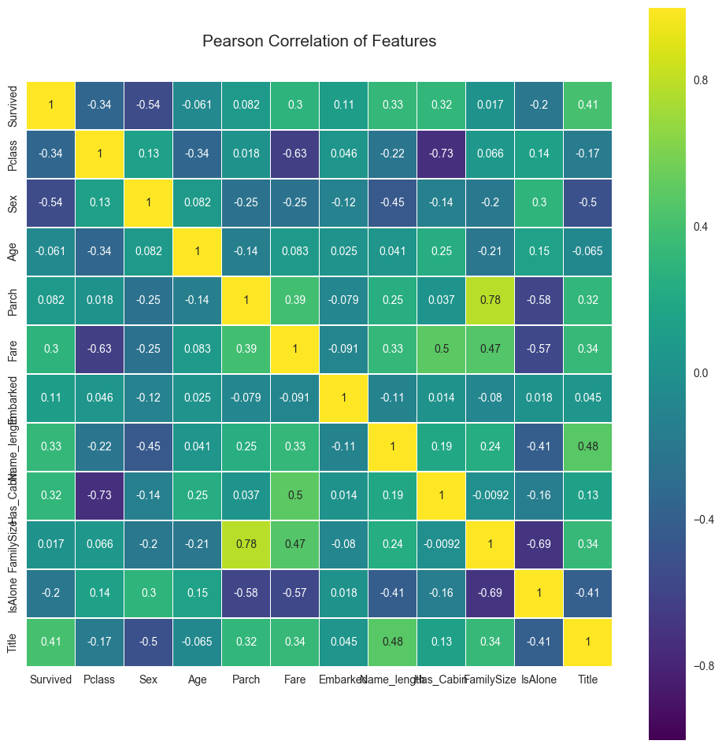

```python
# 用corr()计算特征之间的相关性，可视化，越接近1，越相关
colormap = plt.cm.viridis
plt.figure(figsize=(12,12))
plt.title('Pearson Correlation of Features', y=1.05, size=15)
sns.heatmap(train.astype(float).corr(),linewidths=0.1,vmax=1.0, square=True, cmap=colormap, linecolor='white', annot=True)
```

```python
# 构建数据
y_train = train['Survived'].ravel()
train = train.drop(['Survived'], axis=1)
x_train = train.values # Creates an array of the train data
x_test = test.values # Creats an array of the test data

# X_train = train.drop(['Survived'], axis=1)
# y_train = train['Survived'].ravel()
# X_test = test
print type(x_train),type(y_train),type(x_test)
print x_train.shape, y_train.shape, x_test.shape
```

```
<type 'numpy.ndarray'> <type 'numpy.ndarray'> <type 'numpy.ndarray'>
(891, 11) (891,) (418, 11)
```

```python
# 让PCA自动选择 维度
pca = PCA(n_components='mle')
pca.fit(x_train)
```

```
PCA(copy=True, n_components='mle', whiten=False)
```

```python
# PCA将数据降了1维
print pca.n_components_
print x_train.shape
```

```
10
(891, 11)
```

```python
ntrain = train.shape[0]
ntest = test.shape[0]
SEED = 0 # for reproducibility
NFOLDS = 5 # set folds for out-of-fold prediction
kf = KFold(ntrain, n_folds= NFOLDS, random_state=SEED)
kf
```

```
sklearn.cross_validation.KFold(n=891, n_folds=5, shuffle=False, random_state=0)
```

```python
# Class to extend the Sklearn classifier
class SklearnHelper(object):
    def __init__(self, clf, seed=0, params=None):
        params['random_state'] = seed
        self.clf = clf(**params)

    def train(self, x_train, y_train):
        self.clf.fit(x_train, y_train)

    def predict(self, x):
        return self.clf.predict(x)

    def fit(self,x,y):
        return self.clf.fit(x,y)

    def feature_importances(self,x,y):
        print(self.clf.fit(x,y).feature_importances_)
```

```python
def get_oof(clf, x_train, y_train, x_test):
    oof_train = np.zeros((ntrain,))
    oof_test = np.zeros((ntest,))
    oof_test_skf = np.empty((NFOLDS, ntest))

    for i, (train_index, test_index) in enumerate(kf):
        x_tr = x_train[train_index]
        y_tr = y_train[train_index]
        x_te = x_train[test_index]

        clf.train(x_tr, y_tr)

        oof_train[test_index] = clf.predict(x_te)
        oof_test_skf[i, :] = clf.predict(x_test)

    oof_test[:] = oof_test_skf.mean(axis=0)
    return oof_train.reshape(-1, 1), oof_test.reshape(-1, 1)
```

1. Random Forest classifier
2. Extra Trees classifier
3. AdaBoost classifer
4. Gradient Boosting classifer
5. Support Vector Machine
- n_jobs : Number of cores used for the training process. If set to -1, all cores are used.
- n_estimators : Number of classification trees in your learning model ( set to 10 per default)
- max_depth : Maximum depth of tree, or how much a node should be expanded
- verbose : Controls whether you want to output any text during the learning process. A value of 0 suppresses all text while a value of 3 outputs the tree learning process at every iteration.

```python
# Put in our parameters for said classifiers
# Random Forest parameters
rf_params = {
    'n_jobs': -1, # 电脑有几核，就运行几核
    'n_estimators': 500, # 森林中得树的数量
     'warm_start': True,
     #'max_features': 0.2,
    'max_depth': 6,
    'min_samples_leaf': 2,
    'max_features' : 'sqrt',
    'verbose': 0
}

# Extra Trees Parameters
et_params = {
    'n_jobs': -1,
    'n_estimators':500,
    #'max_features': 0.5,
    'max_depth': 8,
    'min_samples_leaf': 2,
    'verbose': 0
}

# AdaBoost parameters
ada_params = {
    'n_estimators': 500,
    'learning_rate' : 0.75
}

# Gradient Boosting parameters
gb_params = {
    'n_estimators': 500,
     #'max_features': 0.2,
    'max_depth': 5,
    'min_samples_leaf': 2,
    'verbose': 0
}

# Support Vector Classifier parameters
svc_params = {
    'kernel' : 'linear',
    'C' : 0.025
    }
```

```python
# Create 5 objects that represent our 4 models
rf = SklearnHelper(clf=RandomForestClassifier, seed=SEED, params=rf_params)
et = SklearnHelper(clf=ExtraTreesClassifier, seed=SEED, params=et_params)
ada = SklearnHelper(clf=AdaBoostClassifier, seed=SEED, params=ada_params)
gb = SklearnHelper(clf=GradientBoostingClassifier, seed=SEED, params=gb_params)
svc = SklearnHelper(clf=SVC, seed=SEED, params=svc_params)
```

```python
# Create our OOF train and test predictions. These base results will be used as new features
et_oof_train, et_oof_test = get_oof(et, x_train, y_train, x_test) # Extra Trees
rf_oof_train, rf_oof_test = get_oof(rf,x_train, y_train, x_test) # Random Forest
ada_oof_train, ada_oof_test = get_oof(ada, x_train, y_train, x_test) # AdaBoost
gb_oof_train, gb_oof_test = get_oof(gb,x_train, y_train, x_test) # Gradient Boost
svc_oof_train, svc_oof_test = get_oof(svc,x_train, y_train, x_test) # Support Vector Classifier

print("Training is complete")
```

```
Training is complete
```

```python
rf_feature = rf.feature_importances(x_train,y_train)
et_feature = et.feature_importances(x_train, y_train)
ada_feature = ada.feature_importances(x_train, y_train)
gb_feature = gb.feature_importances(x_train,y_train)
```

```
[ 0.12381389  0.20167599  0.0325288   0.0208995   0.07164616  0.02384201
  0.10945962  0.06667224  0.0673959   0.01374384  0.26832206]
[ 0.12195657  0.37656537  0.03204856  0.01677988  0.05534354  0.02809538
  0.04695305  0.08299682  0.04426439  0.02135288  0.17364356]
[ 0.03   0.01   0.014  0.066  0.038  0.008  0.7    0.014  0.05   0.004
  0.066]
[ 0.08281243  0.03137128  0.10076623  0.02796343  0.11670351  0.061857
  0.38458668  0.01614305  0.0692329   0.02757189  0.0809916 ]
```

```python
rf_features = [0.10474135,  0.21837029,  0.04432652,  0.02249159,  0.05432591,  0.02854371
  ,0.07570305,  0.01088129 , 0.24247496,  0.13685733 , 0.06128402]
et_features = [ 0.12165657,  0.37098307  ,0.03129623 , 0.01591611 , 0.05525811 , 0.028157
  ,0.04589793 , 0.02030357 , 0.17289562 , 0.04853517,  0.08910063]
ada_features = [0.028 ,   0.008  ,      0.012   ,     0.05866667,   0.032 ,       0.008
  ,0.04666667 ,  0.     ,      0.05733333,   0.73866667,   0.01066667]
gb_features = [ 0.06796144 , 0.03889349 , 0.07237845 , 0.02628645 , 0.11194395,  0.04778854
  ,0.05965792 , 0.02774745,  0.07462718,  0.4593142 ,  0.01340093]
```

```python
cols = train.columns.values
# Create a dataframe with features
feature_dataframe = pd.DataFrame( {'features': cols,
     'Random Forest feature importances': rf_features,
     'Extra Trees  feature importances': et_features,
      'AdaBoost feature importances': ada_features,
    'Gradient Boost feature importances': gb_features
    })
```

```python
feature_dataframe
```

|  | AdaBoost feature importances | Extra Trees feature importances | Gradient Boost feature importances | Random Forest feature importances | features |
| --- | --- | --- | --- | --- | --- |
| 0 | 0.028000 | 0.121657 | 0.067961 | 0.104741 | Pclass |
| 1 | 0.008000 | 0.370983 | 0.038893 | 0.218370 | Sex |
| 2 | 0.012000 | 0.031296 | 0.072378 | 0.044327 | Age |
| 3 | 0.058667 | 0.015916 | 0.026286 | 0.022492 | Parch |
| 4 | 0.032000 | 0.055258 | 0.111944 | 0.054326 | Fare |
| 5 | 0.008000 | 0.028157 | 0.047789 | 0.028544 | Embarked |
| 6 | 0.046667 | 0.045898 | 0.059658 | 0.075703 | Name_length |
| 7 | 0.000000 | 0.020304 | 0.027747 | 0.010881 | Has_Cabin |
| 8 | 0.057333 | 0.172896 | 0.074627 | 0.242475 | FamilySize |
| 9 | 0.738667 | 0.048535 | 0.459314 | 0.136857 | IsAlone |
| 10 | 0.010667 | 0.089101 | 0.013401 | 0.061284 | Title |

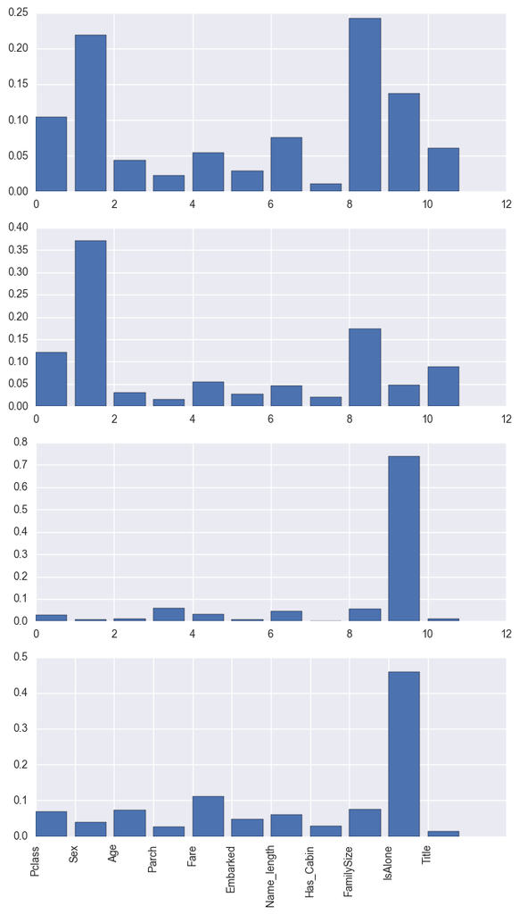

```python
x = range(len(feature_dataframe['features']))
fig = plt.figure(figsize=(8,14))
fig1 = fig.add_subplot(4,1,1)
fig1.bar(x, feature_dataframe['Random Forest feature importances'])
fig2 = fig.add_subplot(4,1,2)
fig2.bar(x, feature_dataframe['Extra Trees  feature importances'])
fig3 = fig.add_subplot(4,1,3)
fig3.bar(x, feature_dataframe['AdaBoost feature importances'])
fig4 = fig.add_subplot(4,1,4)
fig4.bar(x, feature_dataframe['Gradient Boost feature importances'])
plt.xticks(x, feature_dataframe['features'], rotation=90)
plt.show()
```

```python
# Create the new column containing the average of values

feature_dataframe['mean'] = feature_dataframe.mean(axis= 1) # axis = 1 computes the mean row-wise
feature_dataframe.head(3)
```

|  | AdaBoost feature importances | Extra Trees feature importances | Gradient Boost feature importances | Random Forest feature importances | features | mean |
| --- | --- | --- | --- | --- | --- | --- |
| 0 | 0.028 | 0.121657 | 0.067961 | 0.104741 | Pclass | 0.080590 |
| 1 | 0.008 | 0.370983 | 0.038893 | 0.218370 | Sex | 0.159062 |
| 2 | 0.012 | 0.031296 | 0.072378 | 0.044327 | Age | 0.040000 |

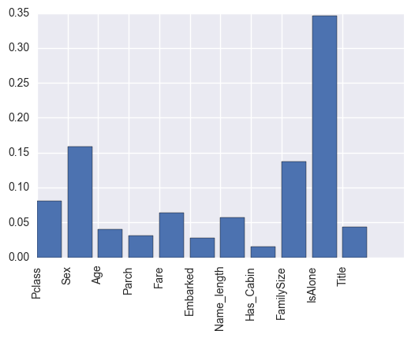

```python
plt.bar(x, feature_dataframe['mean'])
plt.xticks(x, feature_dataframe['features'], rotation=90)
plt.show()
```

```python
base_predictions_train = pd.DataFrame( {'RandomForest': rf_oof_train.ravel(),
     'ExtraTrees': et_oof_train.ravel(),
     'AdaBoost': ada_oof_train.ravel(),
      'GradientBoost': gb_oof_train.ravel(),
        'svc':svc_oof_train.ravel()
    })
base_predictions_train.head()
```

|  | AdaBoost | ExtraTrees | GradientBoost | RandomForest | svc |
| --- | --- | --- | --- | --- | --- |
| 0 | 0.0 | 0.0 | 0.0 | 0.0 | 0.0 |
| 1 | 1.0 | 1.0 | 1.0 | 1.0 | 1.0 |
| 2 | 1.0 | 0.0 | 1.0 | 0.0 | 1.0 |
| 3 | 1.0 | 1.0 | 1.0 | 1.0 | 1.0 |
| 4 | 0.0 | 0.0 | 0.0 | 0.0 | 0.0 |

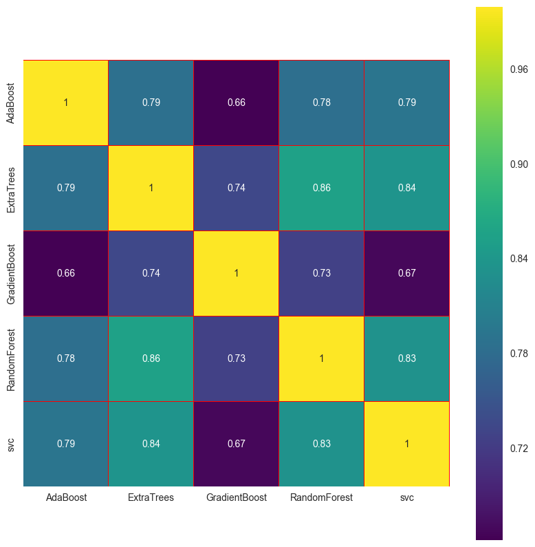

```python
# 来看看不同的模型对测试集进行交叉验证得到的预测值得 相关性
# 可以看到 各模型预测值相关度还是挺高的
colormap = plt.cm.viridis
plt.figure(figsize=(10,10))
sns.heatmap(base_predictions_train.corr(), linewidths=0.1, vmax=1.0, square=True, cmap=colormap, linecolor='r', annot=True)
```

```python
x_train = np.concatenate(( et_oof_train, rf_oof_train, ada_oof_train, gb_oof_train, svc_oof_train), axis=1)
x_test = np.concatenate(( et_oof_test, rf_oof_test, ada_oof_test, gb_oof_test, svc_oof_test), axis=1)
print type(x_train),type(x_test)
print x_train.shape, x_test.shape
```

```
<type 'numpy.ndarray'> <type 'numpy.ndarray'>
(891, 5) (418, 5)
```

```python
gbm = xgb.XGBClassifier(
    learning_rate = 0.02,
 n_estimators= 2000,
 max_depth= 6,
 min_child_weight= 2,
 #gamma=1,
 gamma=0.9,
 subsample=0.8,
 colsample_bytree=0.8,
 objective= 'binary:logistic',
 nthread= -1,
 scale_pos_weight=1).fit(x_train, y_train)

predictions = gbm.predict(x_test)
```

```python
pre_train = gbm.predict(x_train)
# 度量一下他的准确率
from sklearn.metrics import accuracy_score
print accuracy_score(y_train, pre_train)
```

```
0.867564534231
```

```python
# Generate Submission File
StackingSubmission = pd.DataFrame({ 'PassengerId': PassengerId,
                            'Survived': predictions })
StackingSubmission.to_csv("StackingSubmission.csv", index=False)
```